# My microbiome in the jungle

How does travel affect your microbiome? In a famous experiment [published in 2014](http://genomebiology.com/2014/15/7/R89), Duke University scientist Lawrence David tracked the daily microbiomes of two people for an entire year and [found significant differences](http://blog.richardsprague.com/2014/07/microbes-over-time.html) when one of the people travelled outside the U.S. Would the same thing happen to me?

According to my latest uBiome results, the answer is yes. My wife and I recently travelled from our home in Seattle to Central America to celebrate her birthday. We spent most of our time in a rural, jungle part of Belize, about a half hour’s drive from [Benque](http://www.martzfarm.com/), near the border with Guatemala. Besides viewing the fantastic, well-preserved Mayan ruins in the area, we also did horseback riding, cave exploration, and of course plenty of eating.

Here’s a selfie I took in front of the incredibly well-preserved thousand-year-old pyramid at [Tikal](http://www.smithsonianmag.com/history/secrets-of-the-maya-deciphering-tikal-2289808/):

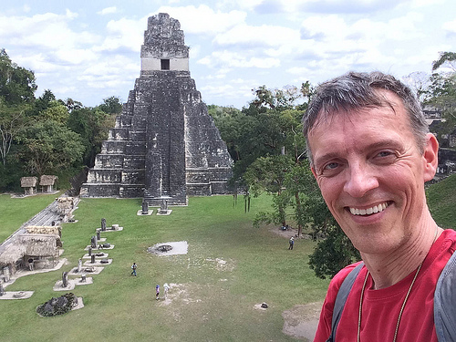

What did the jungle do to my gut? Here’s the uBiome summary of the test I submitted immediately after returning home:

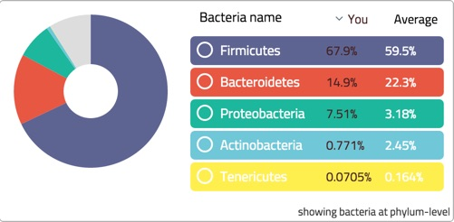

The first thing you might notice is the abundance of the phylum *Firmicutes* compared to “average”, a difference which is often [associated with obesity](http://www.nature.com/nature/journal/v444/n7122/full/4441022a.html). If this had been my only uBiome test, you might think I should have passed on the birthday cake (especially since 23andme also thinks [I’m at risk](http://blog.richardsprague.com/2008/10/whats-in-my-genes-results-from-23andme.html) for obesity). Interestingly, I *did* gain a couple of pounds during the trip, maybe from all that tasty [coconut rice and beans](http://www.belize.com/top-ten-things-to-taste-in-belize).

But a single result can’t tell you much. Since I’ve been testing myself regularly with uBiome for the past year, I have a good idea of what [my “normal” gut biome](http://blog.richardsprague.com/2014/10/whats-in-my-microbiome.html) looks like. Here’s the overall picture through time, including results from my [sleep hacking experiments](http://www.ubiomeblog.com/my-ubiome-sleep-hacking-update/) between October and January (see those big chunks of Actinobacteria, colored brown in the graph?):

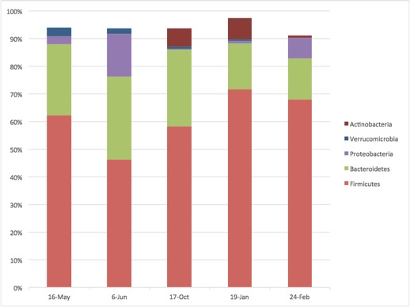

From my previous uBiome results, you can see that my *Firmicutes* levels bounce up and down, but not dramatically, and the jungle doesn’t appear to have changed the major numbers all that much. Incidentally, I soon lost all the extra pounds after returning home to my normal diet.

Looking more closely, nearly all the new *Proteobacteria* are members of the class *Gammaproteobacteria*. Using the [Tree Explorer](https://beta.ubiome.com/#bacTreeExplorer/) on the uBiome sample dashboard page, I dig further and further until I see this:

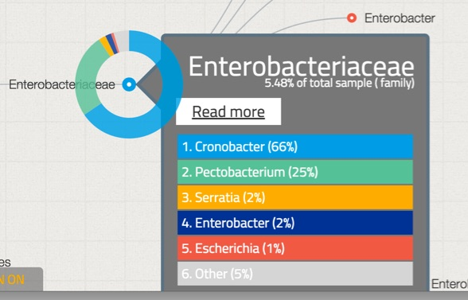

Ouch! Fortunately I never got sick. Why not? The science is just too new to say for sure, but here’s my theory: there is [no such thing as “good” or “bad” bacteria](http://www.nytimes.com/2011/11/01/health/scientist-examines-possible-link-between-antibiotics-and-obesity.html). Everything depends on the *ratios*, on *balance* among lots of competing germs. In my case – and this is my pure, amateur, unscientific speculation – the *Cronobacteria* increase actually *helped* my health, by out-eating something else that may have been even worse.

Here are some reasons I suspect this is true:

- **Diversity**: Oddly, my gut biome diversity went *down* slightly. Before the trip, uBiome found 19 unique phyla. Afterwards, there were only 15. You wouldn’t normally expect diversity to *drop* after exposure to novel microbes from the jungle. But I think there’s an easy explanation:
- **Increase in unidentified organisms**: uBiome was able to identify only about 91% of what it found at the phyla level. In my previous tests, they found closer to 95+%. Maybe my apparent drop in diversity was simply a drop in *identifiable* bacteria. Maybe some of those unknown organisms stimulated the bloom in *Cronobacter*.
- **Clostridium plunge**: I saw huge drops, from 0.66% to 0.18%, in the notorius *Clostridum* genus, which includes many nasty species (e.g. the infamous antibiotic-resistant *C. Difficile*). Other pathogens dropped too. Did the change in location precipitate a fight between competing bacterial armies?
- **Parasites**: the uBiome test only measures bacteria, so I don’t know the status of other microbes I encountered. If *Cronobacteria* are normally pathogenic, is it possible that all their toxicity was aimed at a takeover by some other organism?

My [personal blog](http://blog.richardsprague.com) has more details, including how to use my [free public uBiome analysis tools](https://github.com/richardsprague/uBiome) to compare these samples further.

The Lawrence David study also showed that the microbiome bounced back to normal again pretty quickly after the person returned back home. Will that happen to me? I submitted another uBiome sample this week and I’ll let you know when I get the results.